# Настройка списков управления доступом (ACL)

Отчёт по лабораторной работе 10

Абрикосов Артём

Российский университет дружбы народов, Москва, Россия

13 апреля 2026

# Цели и задачи работы

## Цель лабораторной работы

Освоить настройку прав доступа пользователей к ресурсам сети  
с использованием списков контроля доступа (ACL)  
в Cisco Packet Tracer.

# Построение и настройка сети

## Топология сети

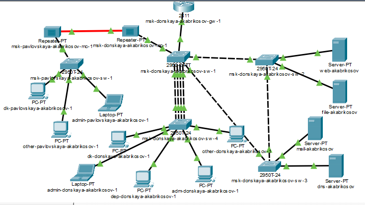

Топология сети с серверами и клиентскими узлами

## Настройка расширенного ACL

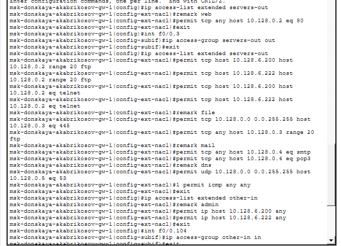

Процесс настройки расширенного ACL на маршрутизаторе

## Применение и проверка ACL

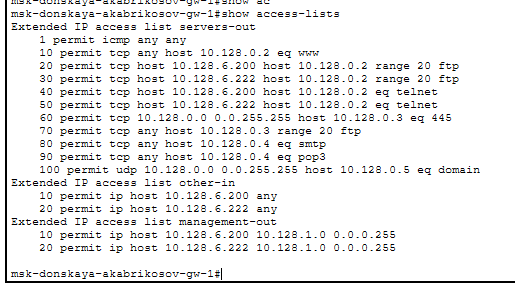

Проверка настроенных списков доступа

# Реализованные правила доступа

## Доступ к серверным ресурсам

- Разрешён доступ к web-серверу по HTTP для всех пользователей
- Для администратора дополнительно разрешены Telnet и FTP
- Для файлового сервера разрешён FTP-доступ и доступ к общим ресурсам
- Для почтового сервера разрешены SMTP и POP3
- Для DNS-сервера разрешены запросы по UDP 53
- Разрешён ICMP-трафик в сеть серверов

## Ограничение доступа для сети Other

- Запрещены обращения пользователей сети Other за пределы своей сети
- Разрешён доступ только для администратора
- Настроен список `management-out`
- Доступ к сети управления разрешён только административным узлам

# Проверка доступа к сервисам

## Проверка доступа к web-серверу

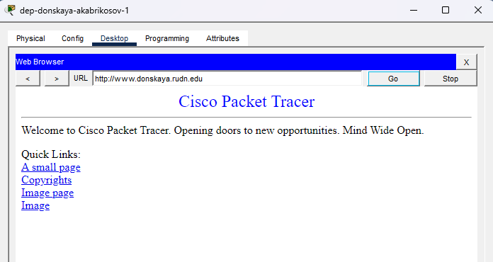

Проверка доступа к web-серверу через браузер

## Ограничение доступа к FTP

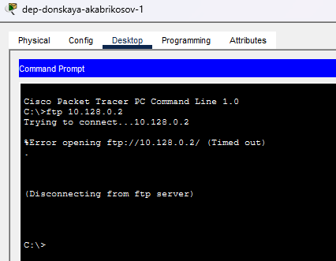

Запрет доступа к FTP для обычного пользователя

## FTP-доступ администратора

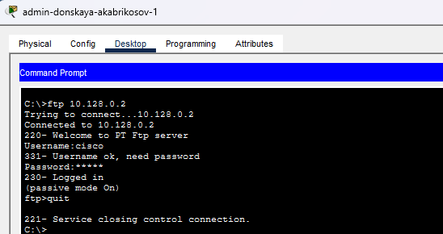

Успешное FTP-подключение администратора

## FTP-доступ с другого административного ПК

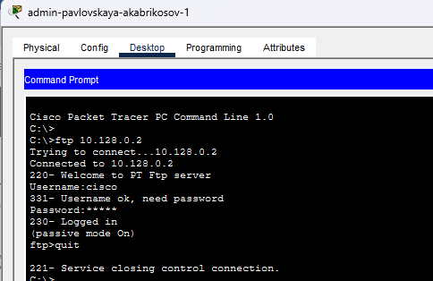

FTP-доступ с другого административного ПК

# Проверка работы серверов

## Подключение к файловому серверу по имени

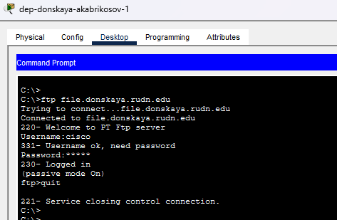

Подключение к файловому серверу по имени

## Настройка почтового сервера

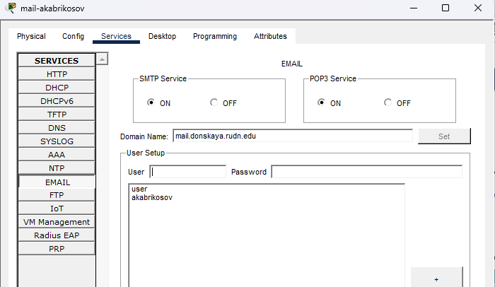

Настройка почтового сервера

## Отправка и получение электронной почты

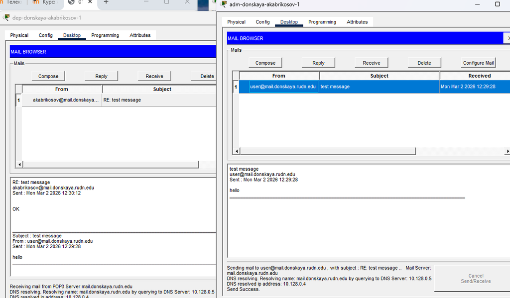

Проверка отправки и получения электронной почты

## Повторная проверка web-доступа

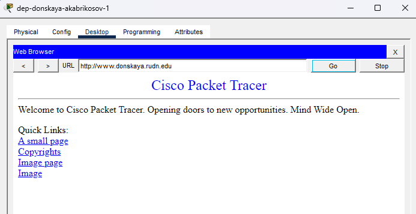

Доступ к web-серверу

# Проверка сетевой связности и управления

## Проверка ICMP-сообщений

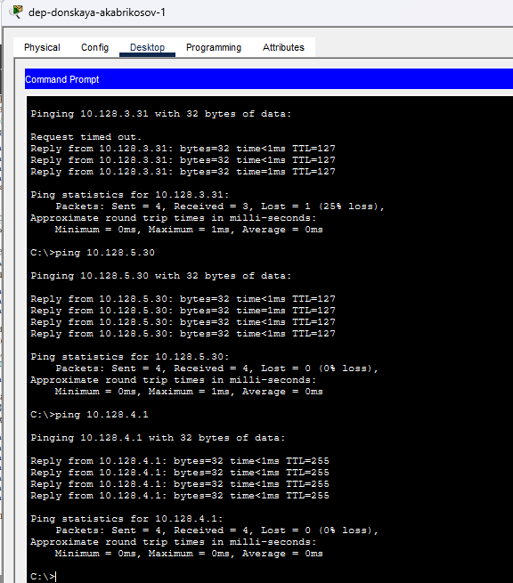

Проверка ICMP-сообщений

## SSH-доступ администратора

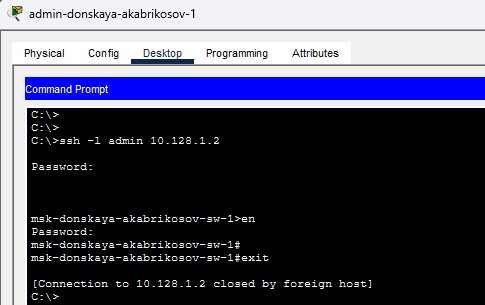

Успешное SSH-подключение администратора

## SSH-доступ второго администратора

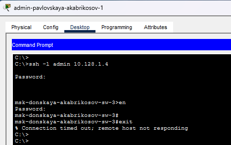

Успешное SSH-подключение второго администратора

# Итоги выполненной работы

## Результаты настройки ACL

- Реализована сегментация сети пользователей и серверов
- Настроены правила фильтрации трафика с использованием расширенных ACL
- Разграничены права обычных пользователей и администратора
- Ограничен доступ из сети Other
- Защищена сеть управления сетевым оборудованием
- Подтверждена корректная работа HTTP, FTP, SMTP, POP3, DNS, ICMP и SSH

# Выводы по проделанной работе

## Вывод

В ходе лабораторной работы в Cisco Packet Tracer была построена сеть  
с сегментацией пользователей и серверов, а также настроены  
списки контроля доступа для фильтрации сетевого трафика.

ACL позволили разграничить доступ к web-, file-, mail- и DNS-серверам,  
а также предоставить расширенные права администраторам.

Проверка показала, что разрешённые сервисы работают корректно,  
а запрещённые подключения для обычных пользователей блокируются.